# Preview for Lecture 2: Counting, Probability, and Bayes Theorem

## Instructor: Dr. Hu Chuan-Peng

## 计数与概率

### 基本概念回顾：概率论基础

- **试验(Trial)**:指对某种现象或过程的一次观察或一次操作。
- **事件(Event)**:是概率的研究对象，是对试验中一组特定结果的统称。
- **概率（Probability）**: 是对某个事件在试验中发生可能性大小的数值刻画。
- **条件概率(Conditional Probability)**:指 “在已知事件 B 发生的前提下，事件 A 发生的概率”。

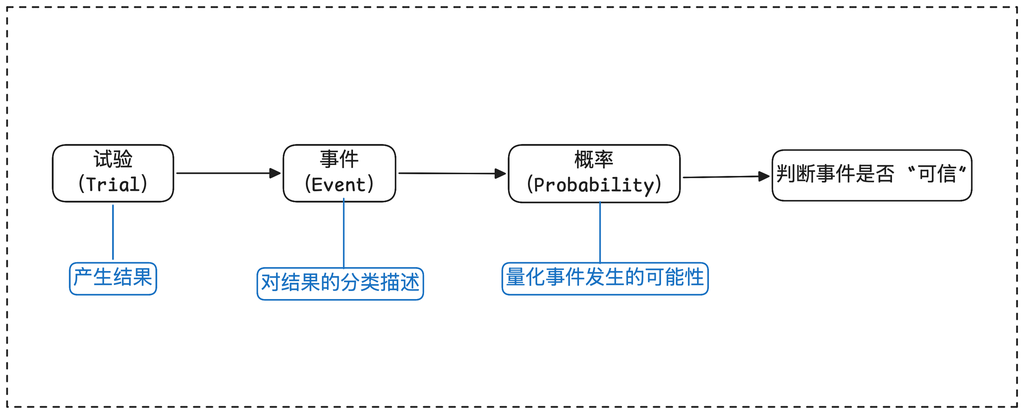

*相关视频推荐（易懂）：*

https://www.bilibili.com/video/BV1B7411v73M?p=14&vd_source=7b2584179c6dc9c18721c42b39ce63b9

https://www.bilibili.com/video/BV1B7411v73M?p=15&vd_source=7b2584179c6dc9c18721c42b39ce63b9

### 概率即计数 (Probability as counting)

下面让我们来做一个推测游戏。

假设一个袋子里有四个鹅卵石，只有两种可能颜色：白色和蓝色。

两种颜色的石头各有几块是未知的 (Source: Statistical rethinking)。

根据已有的信息，可以判断四个石头颜色组合的可能情况有五种：

- "白白白白"
- "蓝白白白"
- "蓝蓝白白"
- "蓝蓝蓝白'
- "蓝蓝蓝蓝"

[figure not shown]

这五种可能性都只是我们的推测（conjecture），而我们要做的，是需要通过从袋子中抽取鹅卵石，来推断哪个一个推测的可能性最大。

*（这与我们通常学习的概率问题有什么差别？）*

假定我们**有放回地**从袋子中依次抽取3个鹅卵石，得到的结果是“蓝色”，“白色”，“蓝色”：

[figure not shown]

这三个石头的及其颜色就是我们得到的**数据（data）**。

假如袋中的鹅卵石的颜色是一蓝三白（5种猜测中的一种），那三次抽取的所有可能颜色组合有64种（$4^3$），如下图所示：

*（每次抽取都有4种可能情况，抽取三次即有$4^3$种可能结果。）*

[figure not shown]

*（从内到外每一个圆弧表示一次抽取。）*

而在所有的可能性中，删除与我们上述观察数据（蓝、白、蓝）不一致的路径后，仅有剩下3条路径：

[figure not shown]

如果我们依次考虑先前的五种可能性（如下图所示），并根据我们的数据（"蓝白蓝"）进行所有可能抽取结果的推测：

[figure not shown]

都考虑完后，即可得到以下结果：

[figure not shown]

例如，我们推测袋子里的小球为"蓝白白白"，

那么基于得到的数据"蓝白蓝"，

- 第一次抽取为"蓝"的可能为1，
- 第二次抽取为"白"的可能为3，
- 第三次抽取为"蓝"的可能仍旧为1（考虑每次抽取后均放回），

所以最终我们的推测得到的总共可能性大小即为1 * 3 * 1 = 3。

*（相信聪明又机智的你一定已经拿捏住该如何计算各种推测的可能性大小啦！）*(*¯︶ ¯*)

[figure not shown]

### 根据新的信息更新我们的信息

假设我们又进行一次抽样，再次得到一个**蓝色鹅卵石**（即 **当前的数据**为"蓝白蓝蓝"）。

这时，我们继续更新一下各种颜色组合的可能性。

更新前：

[figure not shown]

以前三次抽样当作已经知道的信息（先验信息），以此为基础加入第四次抽样的结果，并依次推断袋子中鹅卵石颜色组合的可能性大小：

更新后：

[figure not shown]

我们以第三种猜测（"蓝蓝白白"）为例：

- 对于前三次的抽取，表明有八种方式产生“蓝白蓝”的结果。
- 而在这种猜测的情况之下，第四次抽取又有两种方式产生“蓝色”的石头。

所以，“蓝蓝白白”这种情况一共有$8 \times2 = 16$种方式产生**先前的**数据和**当前的**数据模式。

### 从计数到概率

一般在统计学中，我们更多使用概率而不是计数。

比如，当抽到“蓝-白-蓝”的石头后，我们可以推测袋子里鹅卵石为一蓝三白的概率为：

[figure not shown]

为了将所有推测的概率之和为1，我们要将概率标准化（归一化）：

袋子中蓝色鹅卵石的占比为$p$。

当鹅卵石颜色为三白一蓝时，$p = 0.25$。在五种猜测情况下$p$的概率分别为：

[figure not shown]

那么，**在看到一些数据后，我们对$p$值的信念会发生变化**，这个变化可以通过如下公式获得：

[figure not shown]

• **ways $p$ can produce $D_{new}$（p产生数据的方式数）：** 这就是 似然（Likelihood），记作 $P(D_{new} | p)$。它的意思是：在假设某个p值为真的情况下，我们观察到眼前这份数据（“蓝白蓝”）的可能性有多大？

◦ 例如，当 $p=0.5$（即"蓝蓝白白"）时，计算出抽出“蓝白蓝”的方式有8种。这就是似然值。

• **prior plausibility $p$（p的先验合理性）**： 这就是 先验概率（Prior Probability），记作 $P(p)$。即在看到任何数据之前，你对于某个p假设为真的初始信念。

• **sum of products（方式数乘积的总和）**： 这就是 证据（Evidence） 或 标准化常数，记作 $P(D_{new})$。它是所有可能情况下 (似然 × 先验) 的总和。其作用是确保所有后验概率相加等于1，由此成为一个合理的概率分布。

• **plausibility of $p$ after $D_{new}$（p的后验合理性）**： 这就是我们最终要求的 后验概率（Posterior Probability），记作 $P(p | D_{new})$，指在看到数据之后，我们对**每个$p$假设为真**更新后的、认为最合理的信念程度。

仍然假定数据是“蓝-白-蓝”，则：

[figure not shown]

*（在表格中，我们默认所有p假设（[0, 0.25, 0.5, 0.75, 1]）的先验概率是相等的，可以得到对于这总共5种可能推测，每个p的先验概率（Prior Probability）都是 1/5 = 0.2。p假设指"蓝球个数占所有球个数的比例"，区别于先验概率。）*

继续以"蓝蓝白白"（即$p$假设$p=0.5$)为例，计算一下它的后验概率：

首先计算分子乘积：

- ways × prior= 8 × 0.2 = 1.6

之后计算分母总和： 我们需要计算所有p假设下的乘积，然后求和：

- p=0: 0 × 0.2 = 0
- p=0.25: 3 × 0.2 = 0.6
- p=0.5: 8 × 0.2 = 1.6
- p=0.75: 9 × 0.2 = 1.8
- p=1: 0 × 0.2 = 0 - 总和 = 0 + 0.6 + 1.6 + 1.8 + 0 = 4.0

所以，对于"蓝蓝白白"这种可能推测的后验概率$posterior = 1.6/4.0 = 0.40$，即*plausibility of* $p$ *after* $D_{new}$ 的值为0.40，与表格呈现相符。

在上述例子中，机智的你所掌握到的：

- 猜测同的蓝色石头的比例 $p$: 模型参数(parameter);
- 给定$p$值时，得到某种数据的方式: 似然 (likelihood);
- prior plausibility --> prior probability 先验概率 (prior)
- 在得到数据后，更新后的$p$：后验概率 (posterior)

**概念小结**：

- **模型参数(parameter)**:描述总体特征的未知量。在贝叶斯框架中，参数被视为随机变量，具有概率分布特性。
- **先验（prior）**：指没有观察到具体数据之前，根据已有知识、经验或主观判断对某个事件发生概率的初步估计。
  - 在贝叶斯框架下，先验概率（Prior probability）指在观察数据前对参数分布的假设。
- **似然（likelihood）**：描述的是在不同假设下，某个数据模式出现的可能性。
- **后验 (posterior)**:表示在观测数据条件下参数的概率分布更新.
- **数据(data)**:在贝叶斯框架中，数据是通过实验或观察获得的经验证据(observed data)，其核心功能是通过似然函数（likelihood function）更新先验概率分布（prior probability distribution），从而形成后验概率分布（posterior probability distribution）。

### 本例中与我们先前所学习“统计”的差异：

参数是否已知？

### 模型思维：理论的“小世界”与现实的“大世界”

当哥伦布在1492年寻找新大陆时，他坚信地球是个球体。为了船员在寻找新大陆时可以拥有足够的食物，哥伦布根据3万公里的地球周长计算出来航行所需的物资。

虽然地球的实际周长为4万公里，但幸运的事一路上哥伦布的船队遇到了很多岛屿可供他们提供补给，哥伦布的船队也顺利到达了美洲。

[figure not shown]

在哥伦布的眼中的小地球（3万公里）和现实中的大地球（4万公里）就像是统计中的模型和真实情况。

### 统计学中的*小世界*与*大世界*：

小世界：所有的可能性都是事先设定的

大世界：大世界是部署模型的更广泛的环境（或改为“模型运行的真实环境”）

贝叶斯模型从证据中学习的方式在小世界中可以说是最佳的。

当贝叶斯模型的假设与现实相近时，贝叶斯模型在大世界中也表现良好

#### 一个例子并用Python实现

现在使用我们对p和“plausibility”的定义进行更新：

```python
import numpy as np#导入numy库
```

```python
ways = [0, 3, 8, 9, 0]#生成数据的路径数量，等于表格中的Ways to produce data
```

```python
ways#查看一下ways
```

```
[0, 3, 8, 9, 0]
```

```python
plaus = ways/np.sum(ways)#将ways除ways总和，就是plausibility
plaus
```

```
array([0.  , 0.15, 0.4 , 0.45, 0.  ])
```

```python
p = [0, 0.25, 0.5, 0.75, 1]#推测中鹅卵石为蓝色的占比
```

for 循环

```python
for i, j in zip(p, ways):#zip() 函数用于将可迭代的对象作为参数，将对象中对应的元素打包成一个个元组，然后返回由这些元组组成的列表。
    print(i*j)#将每个i和j乘起来
```

```
0
0.75
4.0
6.75
0
```

新建一个list_products列表，将p和ways相乘后加进去

```python
list_products = [];
for i, j in zip(p, ways):
    list_products.append(i*j)
```

```python
list_products
```

```
[0, 0.75, 4.0, 6.75, 0]
```

新加一个sum_products列表

```python
sum_products = np.sum(list_products)
```

观测到新数据后第二种推测发生的概率为：

```python
(3*0.25)/sum_products
```

```
0.06521739130434782
```

```python
p2 = [0, 0.25, 0.5, 0.75, 1]/np.sum([0, 0.25, 0.5, 0.75, 1])
```

```python
list_products2 = [];
for i, j in zip(p, plaus):
    list_products2.append(i*j)

list_products2
```

```
[0.0, 0.0375, 0.2, 0.3375, 0.0]
```

```python
0.25 * 0.15/np.sum(list_products2)
```

```
0.06521739130434781
```